# Problem Set 4

Christy Smith

3/9/2017

# Submission

1. Fork this repository to your own account
2. Make changes to the `README.Rmd` file (including the author field above).
3. Knit the file to HTML format
4. Publish HTML on Rpubs (you will need to sign up for the free account) and *add the link below*.
5. Submit a PR with your answers.

# Overview

Take the [datacamp course on joining data](https://www.datacamp.com/courses/joining-data-in-r-with-dplyr) to learn the join verbs.

You will analyze some data in the [`nihexporter`](https://github.com/jayhesselberth/nihexporter) package to answer some questions. The questions will cover methods in `dplyr` including two-table verbs.

First you need to install the `nihexporter` package (and `devtools`, if you don’t have it already).

```r
# install.packages('devtools')
devtools::install_github("jayhesselberth/nihexporter")
```

Read the [Overview vignette](http://jayhesselberth.github.io/nihexporter/articles/nihexporter.html) to learn the structure of the pacakge. Take a look at two tables from the package:

```r
library(nihexporter)
library(tidyverse)
library(broom)
projects
```

```
#> # A tibble: 901,059 × 13
#>    application.id institute activity application.type arra.funded
#>             <int>    <fctr>   <fctr>           <fctr>      <fctr>
#> 1         6258248        CA      C06                1          NA
#> 2         6033399        RR      C06                1          NA
#> 3         6039178        RR      C06                1          NA
#> 4         6258225        RR      C06                1          NA
#> 5         6258259        RR      C06                1          NA
#> 6         6258242        RR      C06                1          NA
#> 7         6258249        RR      C06                1          NA
#> 8         6258264        RR      C06                1          NA
#> 9         6254919        RR      C06                1          NA
#> 10        6254932        RR      C06                1          NA
#> # ... with 901,049 more rows, and 8 more variables: project.num <chr>,
#> #   foa.number <fctr>, fiscal.year <int>, project.start <date>,
#> #   project.end <date>, study.section <fctr>, suffix <fctr>, fy.cost <dbl>
```

```r
project_io
```

```
#> # A tibble: 224,899 × 4
#>    project.num n.pubs n.patents total.cost
#>          <chr>  <int>     <int>      <dbl>
#> 1  C06CA091516      1         1    1488000
#> 2  C06RR013577      1         1     329812
#> 3  C06RR014469      3         1    1000000
#> 4  C06RR014488      1         1    1000000
#> 5  C06RR014489     17         1    1250000
#> 6  C06RR014510      1         1     977434
#> 7  C06RR014517      1         1    1032334
#> 8  C06RR014520      1         1    1000000
#> 9  C06RR014524      1         1    1999999
#> 10 C06RR014527      1         1     852265
#> # ... with 224,889 more rows
```

# Notes to self: project.num is the main ID that you can use to link tables together. “RCR” refers to relative citation ratio (impact factor for a manuscript).

## Problem 1

The `projects` and `project_io` tables have the project.num column in common. Use this column to perform a `left_join` and identify the most expensive project for each institute. Project institutes are in the `projects` table, whereas total project costs are available in the `project_io` table. Note you will have to use the `arrange` and `slice` verbs from `dplyr`.

```r
projects %>%
  select(project.num, institute) %>%
  left_join(project_io) %>%
  select(project.num, institute, total.cost) %>%
  group_by(institute) %>%
  arrange(desc(total.cost)) %>%
  slice(1:1) %>%
  arrange(desc(total.cost))
```

```
#> Source: local data frame [25 x 3]
#> Groups: institute [25]
#>
#>    project.num institute total.cost
#>          <chr>    <fctr>      <dbl>
#> 1  ZIHLM200888        LM 1544981304
#> 2  ZIFBC000001        CA  652060692
#> 3  U54HG003067        HG  527942706
#> 4  ZIFAI000001        AI  389496063
#> 5  U01AG009740        AG  219008592
#> 6  U01DK061230        DK  199581387
#> 7  P51RR000166        RR  161140557
#> 8  ZIFHL000001        HL  151243202
#> 9  ZIFMH000001        MH  149352161
#> 10 U01HD052102        HD  147186026
#> # ... with 15 more rows
```

## Problem 2

Create a plot that describes the change in output (number of publications) for the most expensive grant from the above list. Note that you cannot use `n.pubs` for this, as that is an aggregate count over time. You need a tbl of following structure, which you can then use to calculate the number of publications each year (hint: use `n()` in a `summarize` statement:

```r
projects %>%
  head() %>%
  left_join(publinks) %>%
  left_join(publications) %>%
  select(project.num, fiscal.year, fy.cost, pmid) %>%
  na.omit()
```

```
#> # A tibble: 5 × 4
#>   project.num fiscal.year fy.cost     pmid
#>         <chr>       <int>   <dbl>    <int>
#> 1 C06RR014469        2000   1e+06 17621683
#> 2 C06RR014469        2000   1e+06 24059281
#> 3 C06RR014469        2000   1e+06 24976670
#> 4 C06RR014469        2000   1e+06 25980177
#> 5 C06RR014520        2000   1e+06 19299563
```

```r
projects %>%
  select(project.num, institute) %>%
  left_join(project_io) %>%
  select(project.num, institute, total.cost) %>%
  group_by(institute) %>%
  arrange(desc(total.cost)) %>%
  slice(1:1) %>%
  arrange(desc(total.cost)) %>%
  ungroup %>%
  slice(1:1) -> most_expens_proj
```

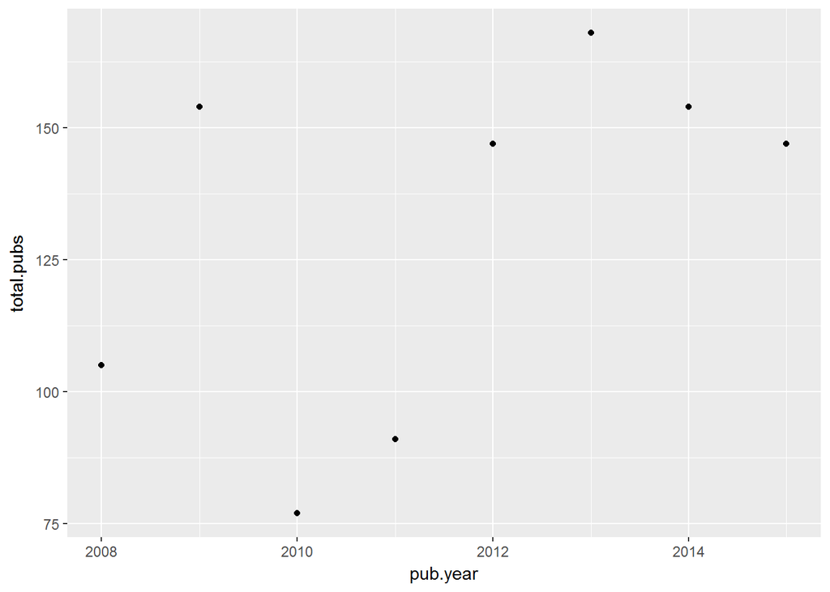

```r
projects %>%
  semi_join(most_expens_proj) %>%
  left_join(publinks) %>%
  left_join(publications) %>%
  select(project.num, pub.year, fy.cost, pmid) %>%
  group_by(pub.year) %>%
  summarize(total.pubs =n()) %>%
  ggplot(aes(x=pub.year, y=total.pubs)) + geom_point()
```

## Problem 3

Use the `projects` and `clinical_studies` table to calculate how many clinical studies have been started by projects from each institute.

```r
projects %>%
  select(institute, project.num) %>%
  left_join(clinical_studies) %>%
  select(institute, project.num, trial.id) %>%
  filter(!is.na(trial.id)) %>%
  group_by(institute) %>%
  summarise(n_distinct(trial.id))
```

```
#> # A tibble: 25 × 2
#>    institute `n_distinct(trial.id)`
#>       <fctr>                  <int>
#> 1         AA                    296
#> 2         AG                    519
#> 3         AI                    419
#> 4         AR                    267
#> 5         AT                    559
#> 6         CA                   5232
#> 7         DA                   1157
#> 8         DC                    103
#> 9         DE                    109
#> 10        DK                    915
#> # ... with 15 more rows
```

## Problem 4

Calculate correlations between `total.cost` and `n.pubs` for each institute. You will need to `join` the `projects` and `project_io` tables to link `institute` with `total.cost` and `n.pubs`. You will then need to use `group_by` and `do` from `dplyr` and `tidy` from `broom` to calculate correlations.

```r
projects %>%
  left_join(project_io) %>%
  select(institute, n.pubs, total.cost) %>%
  filter(!is.na(n.pubs), !is.na(total.cost)) %>%
  group_by(institute) %>%
  do(tidy(cor.test(.$n.pubs, .$total.cost)))
```

```
#> Source: local data frame [25 x 9]
#> Groups: institute [25]
#>
#>    institute  estimate statistic p.value parameter  conf.low conf.high
#>       <fctr>     <dbl>     <dbl>   <dbl>     <int>     <dbl>     <dbl>
#> 1         AA 0.6623385 115.45642       0     17056 0.6538305 0.6706790
#> 2         AG 0.6113984 147.62050       0     36505 0.6049343 0.6177818
#> 3         AI 0.5102040 174.54288       0     86570 0.5052599 0.5151146
#> 4         AR 0.4897399  85.22133       0     23018 0.4798576 0.4994980
#> 5         AT 0.6334686  56.81426       0      4816 0.6162540 0.6500781
#> 6         CA 0.5147985 211.68016       0    124269 0.5107004 0.5188732
#> 7         DA 0.5437862 124.71231       0     37044 0.5365743 0.5509186
#> 8         DC 0.6954540 133.16016       0     18930 0.6880253 0.7027371
#> 9         DE 0.4731841  65.20438       0     14737 0.4605581 0.4856187
#> 10        DK 0.4101026 123.27261       0     75158 0.4041384 0.4160320
#> # ... with 15 more rows, and 2 more variables: method <fctr>,
#> #   alternative <fctr>
```

## Problem 5 (extra credit)

Correlate [`rcr`](https://icite.od.nih.gov/) values from the `publications` table to one of:

- total cost (overall for NIH, or by institute)
- budget mechanism (e.g., RFA, PAR, etc.)
- type of grant (e.g. R01, P01, R21, etc.).

# I used total cost per institute.

```r
projects %>%
  left_join(project_io) %>%
  select(institute, project.num, total.cost) %>%
  left_join(publinks) %>%
  filter(!is.na(pmid)) %>%
  left_join(publications) %>%
  select(institute, total.cost, rcr) %>%
  filter(!is.na(rcr), !is.na(total.cost)) %>%
  group_by(institute) %>%
  do(tidy(cor.test(.$total.cost, .$rcr)))
```

```
#> Source: local data frame [25 x 9]
#> Groups: institute [25]
#>
#>    institute    estimate statistic       p.value parameter     conf.low
#>       <fctr>       <dbl>     <dbl>         <dbl>     <int>        <dbl>
#> 1         AA  0.04126527 24.682192 2.155333e-134    357156  0.037990830
#> 2         AG  0.01487706 17.567534  4.443221e-69   1394092  0.013217406
#> 3         AI  0.01583085 21.189359  1.231471e-99   1791094  0.014366684
#> 4         AR  0.04055562 29.027732 4.161571e-185    511457  0.037819245
#> 5         AT -0.03316985 -7.772965  7.799788e-15     54854 -0.041526633
#> 6         CA  0.01006831 24.007095 2.379278e-127   5684886  0.009246361
#> 7         DA  0.01186620 10.374909  3.237669e-25    764335  0.009624615
#> 8         DC  0.04007725 22.095625 4.240192e-108    303472  0.036524608
#> 9         DE  0.04532023 22.002545 3.495178e-107    235217  0.041286573
#> 10        DK  0.02719820 40.037916  0.000000e+00   2165415  0.025867222
#> # ... with 15 more rows, and 3 more variables: conf.high <dbl>,
#> #   method <fctr>, alternative <fctr>
```

## Problem 6 (extra extra credit)

Use [`gganimate`](https://github.com/dgrtwo/gganimate) to illustrate the change in cost of R01s for a few institutes over time.

```r
library(gapminder)
```

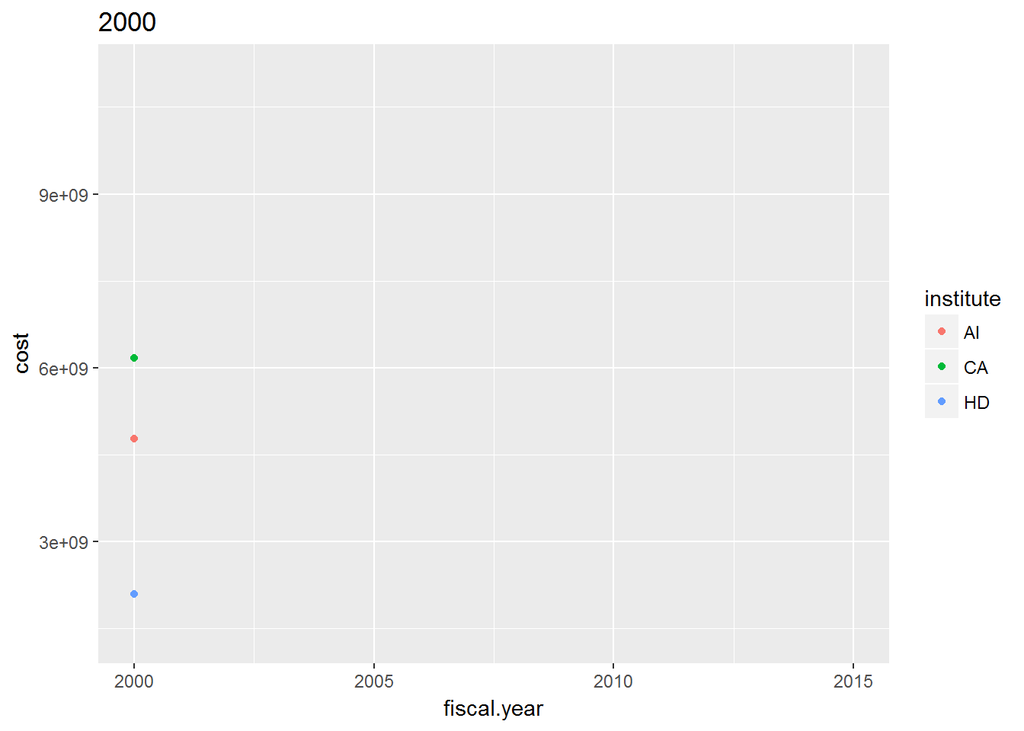

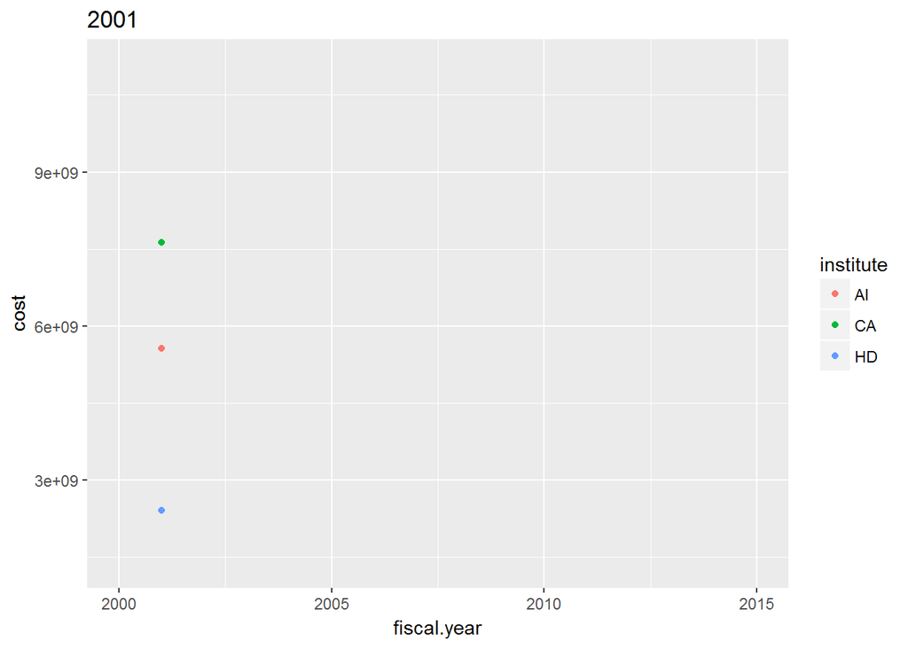

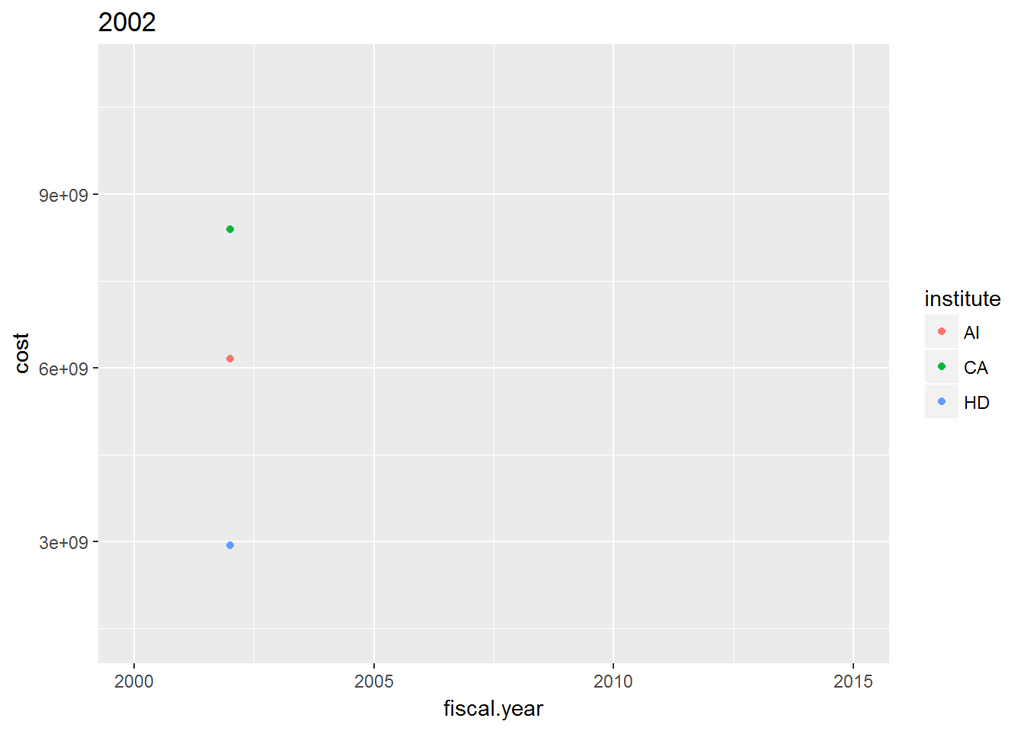

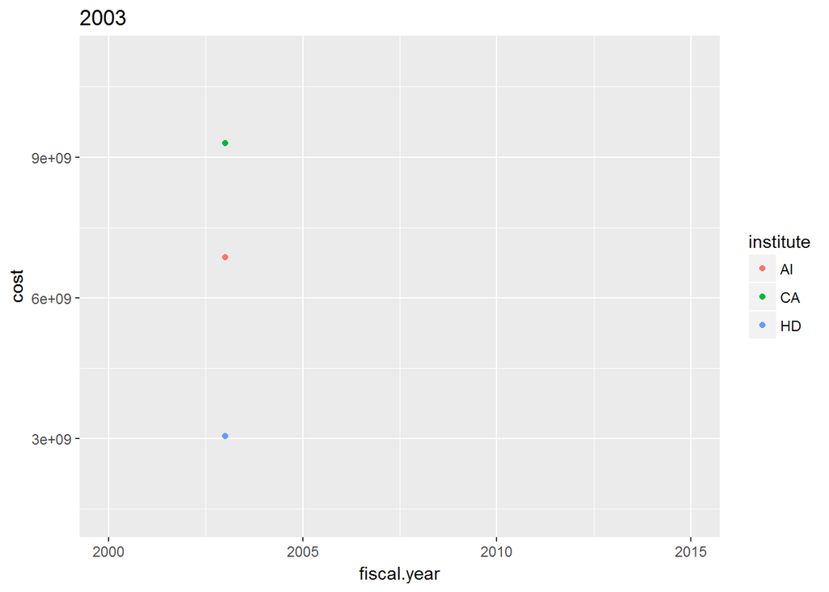

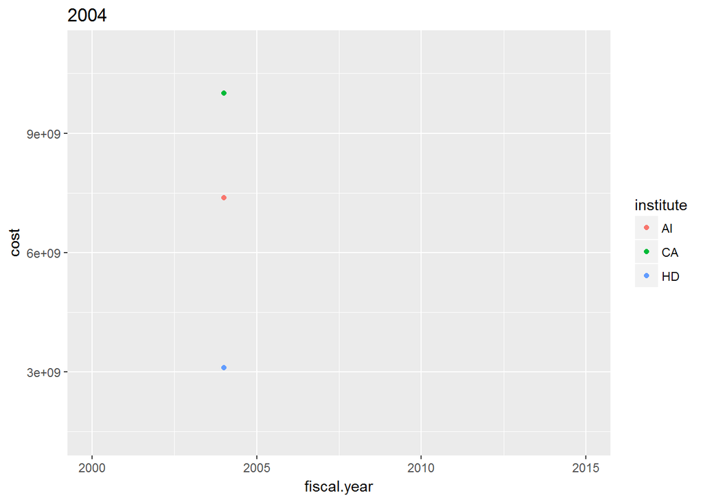

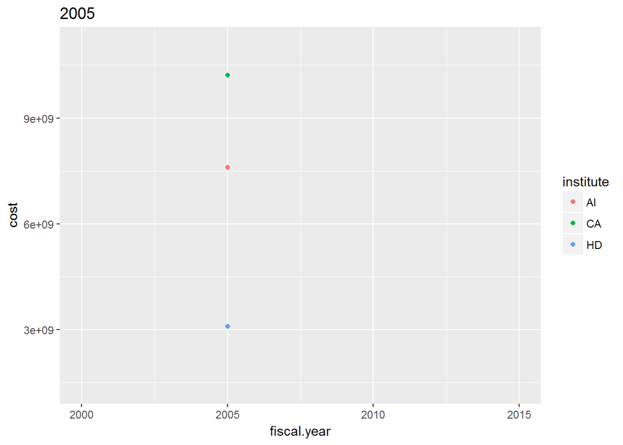

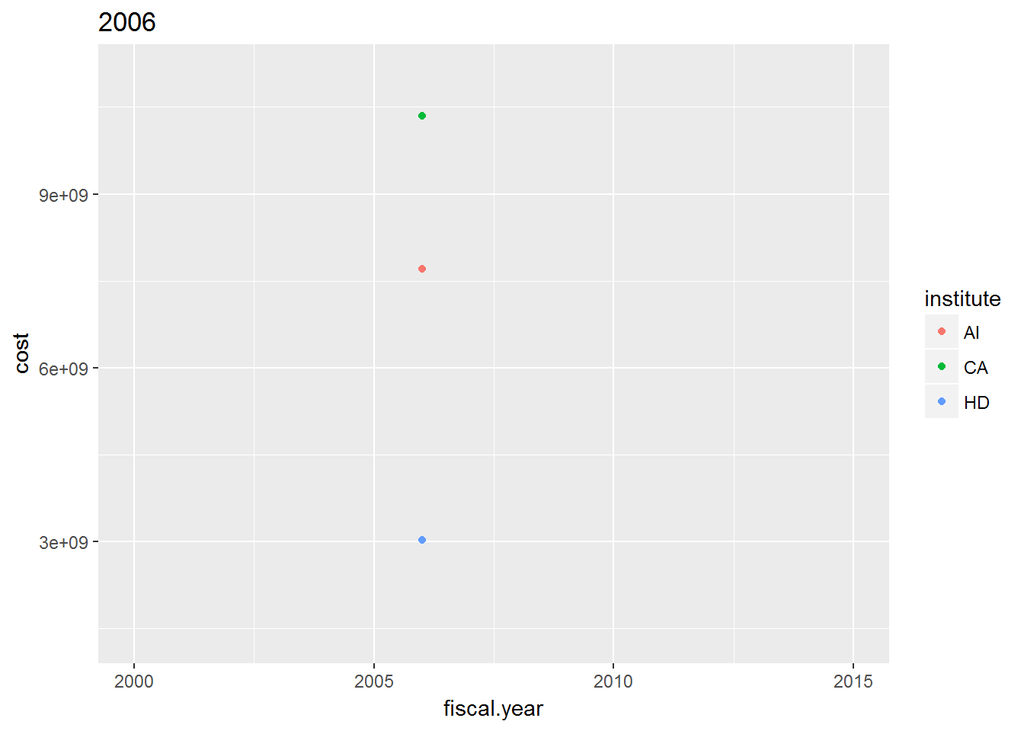

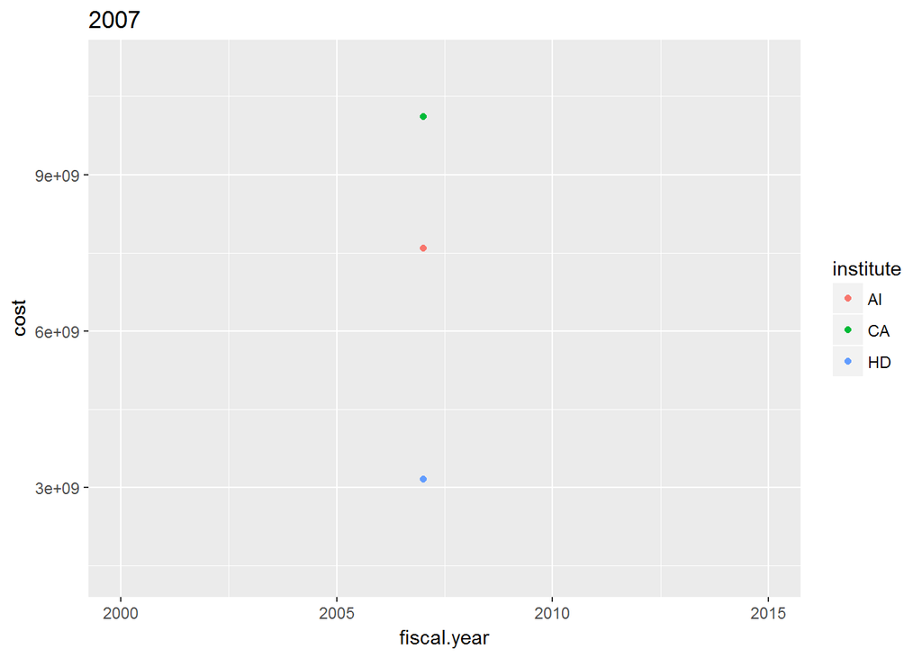

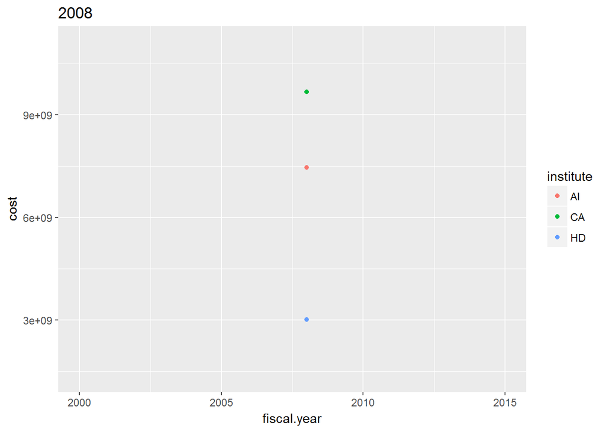

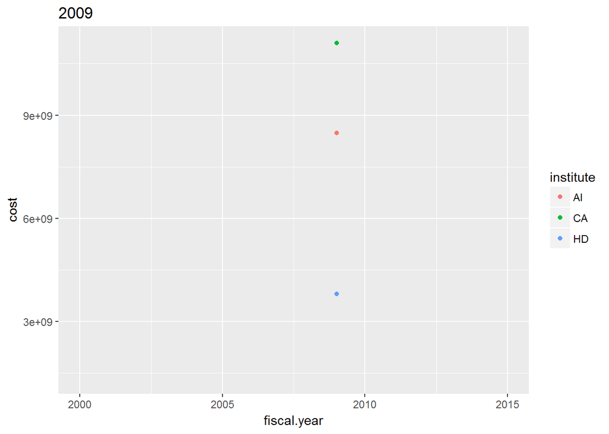

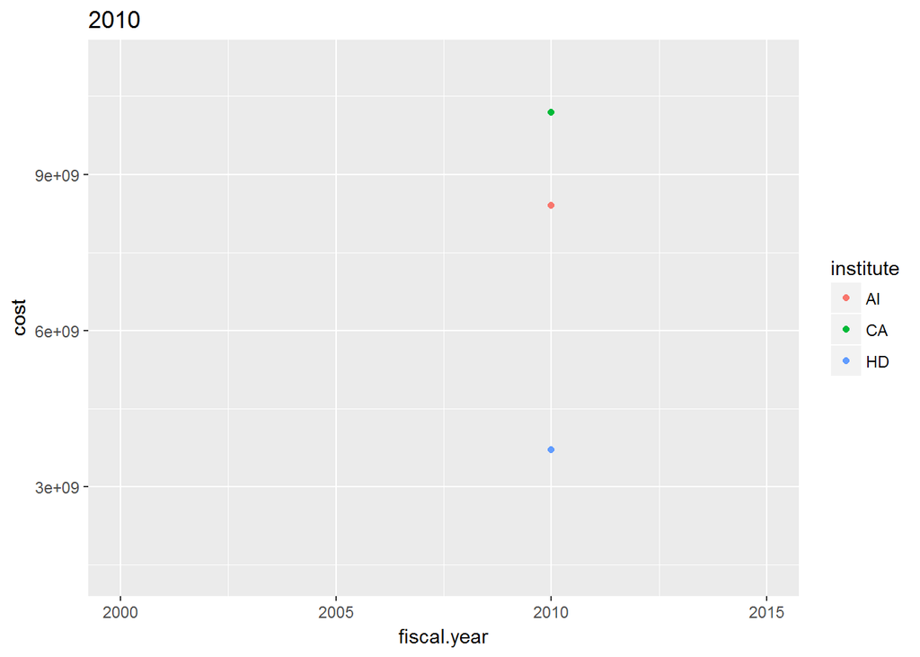

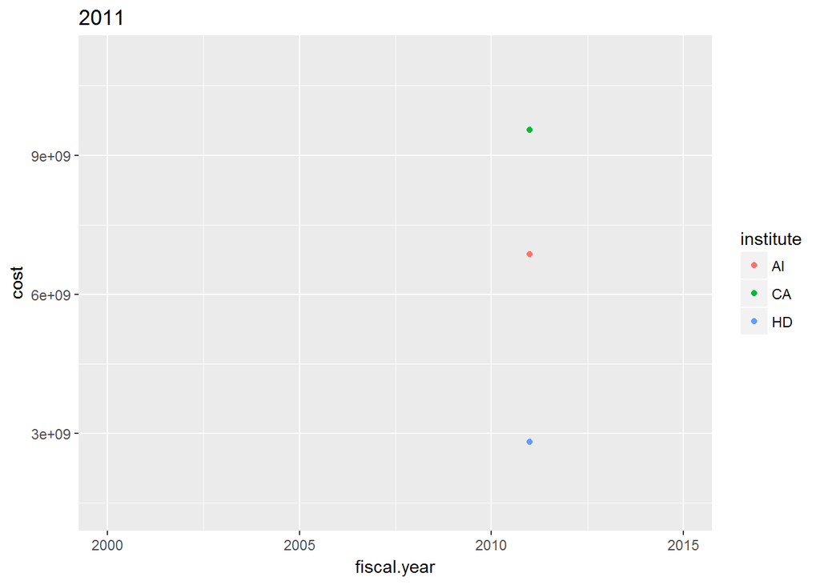

[4 more figures not shown]

```r
library(ggplot2)
library(gganimate)

projects %>%
  filter(activity == "R01") %>%
  select(institute, project.num, fiscal.year) %>%
  left_join(project_io) %>%
  filter(institute == "AI" | institute == "CA" | institute == "HD") %>%
  select(institute, fiscal.year, total.cost) %>%
  filter(!is.na(total.cost)) %>%
  group_by(institute, fiscal.year) %>%
  summarize(cost = sum(total.cost)) %>%
  ggplot(aes(x=fiscal.year, y=cost, color=institute, frame=fiscal.year)) + geom_point() -> p
gganimate(p)
```